# Ch 7 exercises

```r
summary(martello.lm)
```

```
Call:
lm(formula = hcp60 ~ group * sex, data = df)

Residuals:
    Min      1Q  Median      3Q     Max
-10.636  -2.667  -0.455   3.167   9.364

Coefficients:
              Estimate Std. Error t value Pr(>|t|)
(Intercept)      30.64       1.44   21.29  < 2e-16 ***
groupTRT         -9.97       2.15   -4.65  4.4e-05 ***
sexM             -3.75       2.15   -1.75    0.089 .
groupTRT:sexM     1.54       3.03    0.51    0.616
---
Signif. codes:  0 ‘***’ 0.001 ‘**’ 0.01 ‘*’ 0.05 ‘.’ 0.1 ‘ ’ 1

Residual standard error: 4.77 on 36 degrees of freedom
Multiple R-squared:  0.548, Adjusted R-squared:  0.511
F-statistic: 14.6 on 3 and 36 DF,  p-value: 2.25e-06
```

```r
Anova(martello.lm, type='III')
```

```
Anova Table (Type III tests)

Response: hcp60
            Sum Sq Df F value  Pr(>F)
(Intercept)  10324  1  453.18 < 2e-16 ***
group          492  1   21.60 4.4e-05 ***
sex             70  1    3.05   0.089 .
group:sex        6  1    0.26   0.616
Residuals      820 36
---
Signif. codes:  0 ‘***’ 0.001 ‘**’ 0.01 ‘*’ 0.05 ‘.’ 0.1 ‘ ’ 1
```

```r
emmeans(martello.lm, ~ group:sex)
```

```
 group sex emmean   SE df lower.CL upper.CL
 CTR   F     30.6 1.44 36     27.7     33.6
 TRT   F     20.7 1.59 36     17.4     23.9
 CTR   M     26.9 1.59 36     23.7     30.1
 TRT   M     18.4 1.44 36     15.5     21.4

Confidence level used: 0.95
```

```
dv column detected: hcp60
No id column passed. Assuming all rows are independent samples.
```

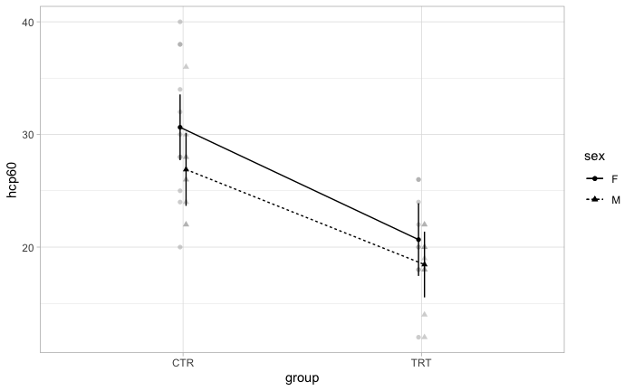

```r
afex_plot(martello.lm, "group", "sex", dodge=0.05)+theme_light()
```

> Data distributions look OK. Model fit is reasonable overall r² is OK Analysis suggests effects of treatment, but no interaction. Inspection of means suggests a decrease of 8-10 on the scale.

**Would including desexing in the analysis improve the model fit or the conclusions?**

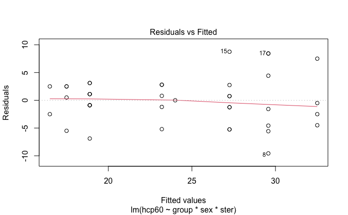

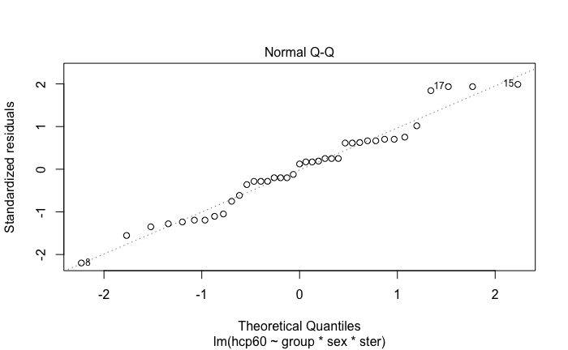

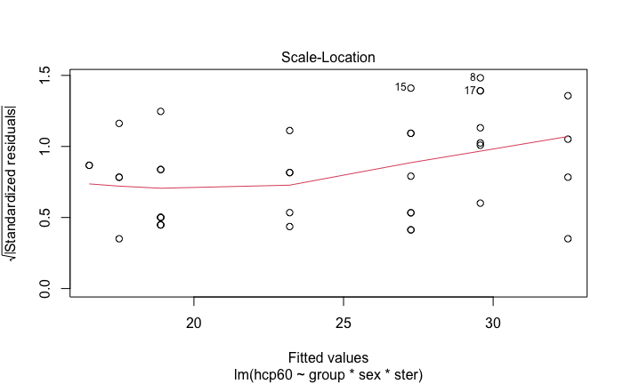

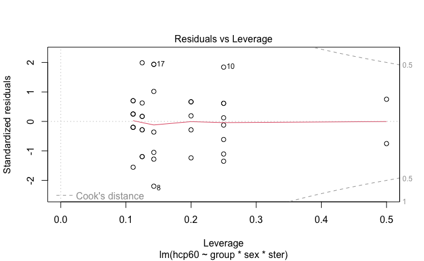

```r
martello2.lm <- lm(hcp60~group*sex*ster, data=df)
plot(martello2.lm)
```

```r
summary(martello2.lm)
```

```
Call:
lm(formula = hcp60 ~ group * sex * ster, data = df)

Residuals:
   Min     1Q Median     3Q    Max
 -9.57  -2.50   0.25   2.56   8.75

Coefficients:
                    Estimate Std. Error t value Pr(>|t|)
(Intercept)            29.57       1.78   16.64   <2e-16 ***
groupTRT               -6.37       2.75   -2.31    0.027 *
sexM                   -2.32       2.43   -0.95    0.347
sterS                   2.93       2.95    0.99    0.328
groupTRT:sexM          -1.99       3.58   -0.56    0.582
groupTRT:sterS         -8.63       4.32   -2.00    0.054 .
sexM:sterS             -6.18       5.79   -1.07    0.294
groupTRT:sexM:sterS     9.49       7.55    1.26    0.218
---
Signif. codes:  0 ‘***’ 0.001 ‘**’ 0.01 ‘*’ 0.05 ‘.’ 0.1 ‘ ’ 1

Residual standard error: 4.7 on 32 degrees of freedom
Multiple R-squared:  0.611, Adjusted R-squared:  0.525
F-statistic: 7.17 on 7 and 32 DF,  p-value: 3.57e-05
```

```r
Anova(martello2.lm, type='III')
```

```
Anova Table (Type III tests)

Response: hcp60
               Sum Sq Df F value Pr(>F)
(Intercept)      6121  1  276.90 <2e-16 ***
group             118  1    5.36  0.027 *
sex                20  1    0.91  0.347
ster               22  1    0.99  0.328
group:sex           7  1    0.31  0.582
group:ster         88  1    4.00  0.054 .
sex:ster           25  1    1.14  0.294
group:sex:ster     35  1    1.58  0.218
Residuals         707 32
---
Signif. codes:  0 ‘***’ 0.001 ‘**’ 0.01 ‘*’ 0.05 ‘.’ 0.1 ‘ ’ 1
```

```r
emmeans(martello2.lm, ~group)
```

```
NOTE: Results may be misleading due to involvement in interactions
```

```
 group emmean   SE df lower.CL upper.CL
 CTR     28.3 1.45 32     25.4     31.3
 TRT     19.0 1.21 32     16.6     21.5

Results are averaged over the levels of: sex, ster
Confidence level used: 0.95
```

> Model fit improves by 5%, as measured by r² No real change to conclusions Sterilization doesn’t have much effect, though the treatment x ster interaction may be worth looking at.

**Anything else worth checking?**

Have a think about the analysis and the experimental design. We’ve analyzed the dogs’ status at the end of the experiment, and relied on randomization to keep us away from misleading results. Think about how you might use the measurements at time 0 to do some additional checks or analyses. Think of a couple of ways and then investigate them.

> Option 1 is to analyze the time 0 values.

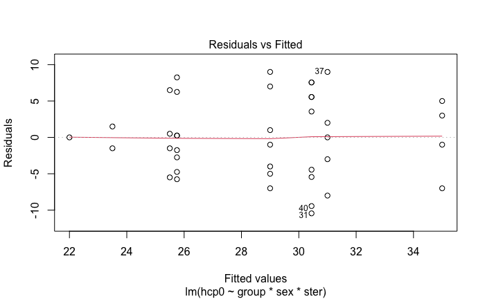

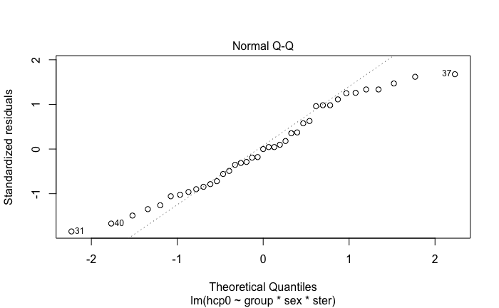

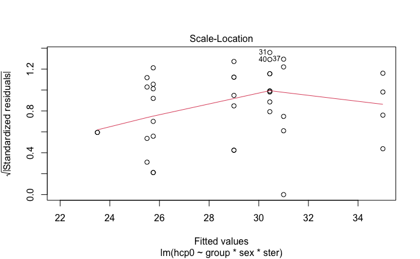

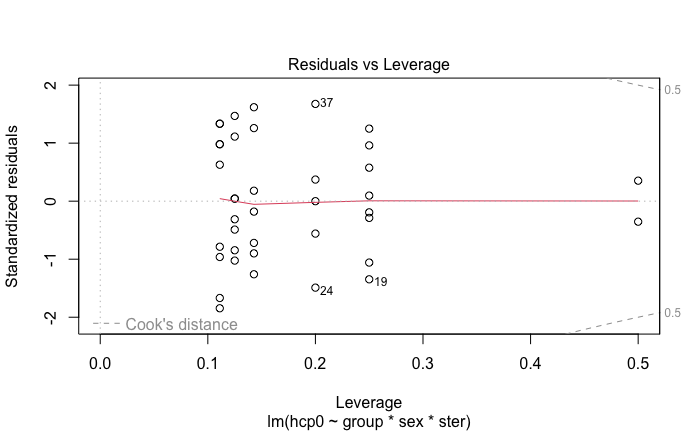

```r
martello3.lm <- lm(hcp0~group*sex*ster, data=df)
plot(martello3.lm)
```

```r
summary(martello3.lm)
```

```
Call:
lm(formula = hcp0 ~ group * sex * ster, data = df)

Residuals:
   Min     1Q Median     3Q    Max
-10.44  -4.52   0.00   5.14   9.00

Coefficients:
                    Estimate Std. Error t value Pr(>|t|)
(Intercept)            29.00       2.27   12.78  4.1e-14 ***
groupTRT                2.00       3.52    0.57    0.573
sexM                   -3.25       3.11   -1.05    0.303
sterS                   6.00       3.76    1.59    0.121
groupTRT:sexM           2.69       4.57    0.59    0.559
groupTRT:sterS        -11.50       5.51   -2.09    0.045 *
sexM:sterS             -9.75       7.40   -1.32    0.197
groupTRT:sexM:sterS     8.31       9.64    0.86    0.395
---
Signif. codes:  0 ‘***’ 0.001 ‘**’ 0.01 ‘*’ 0.05 ‘.’ 0.1 ‘ ’ 1

Residual standard error: 6 on 32 degrees of freedom
Multiple R-squared:  0.268, Adjusted R-squared:  0.108
F-statistic: 1.68 on 7 and 32 DF,  p-value: 0.15
```

```r
Anova(martello3.lm, type='III')
```

```
Anova Table (Type III tests)

Response: hcp0
               Sum Sq Df F value  Pr(>F)
(Intercept)      5887  1  163.35 4.1e-14 ***
group              12  1    0.32   0.573
sex                39  1    1.09   0.303
ster               92  1    2.54   0.121
group:sex          13  1    0.35   0.559
group:ster        157  1    4.35   0.045 *
sex:ster           63  1    1.74   0.197
group:sex:ster     27  1    0.74   0.395
Residuals        1153 32
---
Signif. codes:  0 ‘***’ 0.001 ‘**’ 0.01 ‘*’ 0.05 ‘.’ 0.1 ‘ ’ 1
```

```r
emmeans(martello3.lm, ~ group:ster)
```

```
NOTE: Results may be misleading due to involvement in interactions
```

```
 group ster emmean   SE df lower.CL upper.CL
 CTR   N      27.4 1.55 32     24.2     30.5
 TRT   N      30.7 1.67 32     27.3     34.1
 CTR   S      28.5 3.36 32     21.7     35.3
 TRT   S      24.5 2.60 32     19.2     29.8

Results are averaged over the levels of: sex
Confidence level used: 0.95
```

> Interestingly, this analysis suggests a difference. The formal test suggests treatment x sterilization difference at the start, with sterilized dogs in the actual treatment starting with lower HCPIs

> Option 2 is to measure change in HCPI for each dog

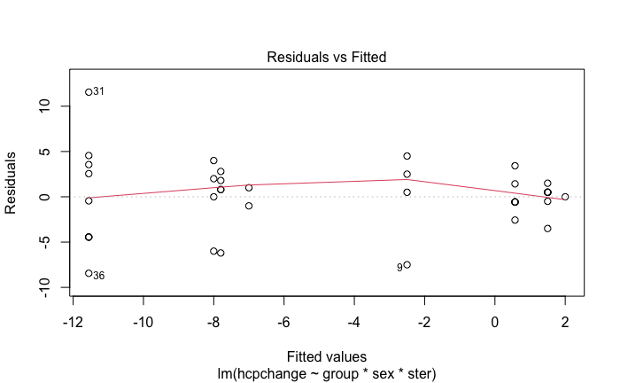

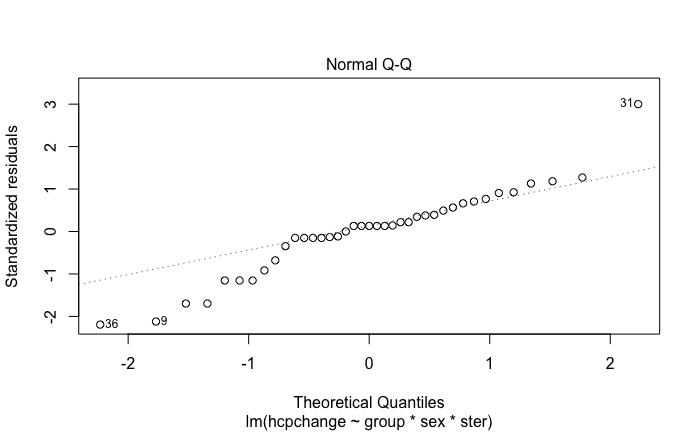

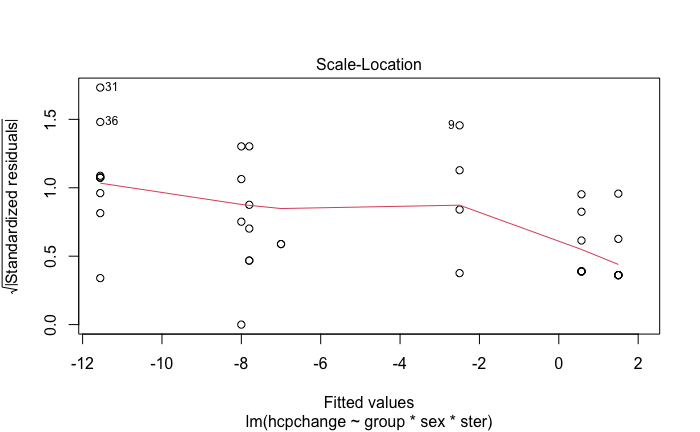

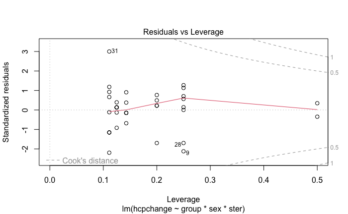

```r
df$hcpchange<-df$hcp60-df$hcp0
martello4.lm <- lm(hcpchange~group*sex*ster, data=df)
plot(martello4.lm)
```

```r
summary(martello4.lm)
```

```
Call:
lm(formula = hcpchange ~ group * sex * ster, data = df)

Residuals:
   Min     1Q Median     3Q    Max
-8.444 -0.679  0.500  1.850 11.556

Coefficients:
                    Estimate Std. Error t value Pr(>|t|)
(Intercept)            0.571      1.544    0.37   0.7137
groupTRT              -8.371      2.391   -3.50   0.0014 **
sexM                   0.929      2.114    0.44   0.6634
sterS                 -3.071      2.560   -1.20   0.2390
groupTRT:sexM         -4.684      3.108   -1.51   0.1415
groupTRT:sterS         2.871      3.749    0.77   0.4494
sexM:sterS             3.571      5.032    0.71   0.4830
groupTRT:sexM:sterS    1.184      6.559    0.18   0.8579
---
Signif. codes:  0 ‘***’ 0.001 ‘**’ 0.01 ‘*’ 0.05 ‘.’ 0.1 ‘ ’ 1

Residual standard error: 4.08 on 32 degrees of freedom
Multiple R-squared:  0.671, Adjusted R-squared:  0.599
F-statistic: 9.34 on 7 and 32 DF,  p-value: 2.93e-06
```

```r
Anova(martello4.lm, type='III')
```

```
Anova Table (Type III tests)

Response: hcpchange
               Sum Sq Df F value Pr(>F)
(Intercept)         2  1    0.14 0.7137
group             204  1   12.25 0.0014 **
sex                 3  1    0.19 0.6634
ster               24  1    1.44 0.2390
group:sex          38  1    2.27 0.1415
group:ster         10  1    0.59 0.4494
sex:ster            8  1    0.50 0.4830
group:sex:ster      1  1    0.03 0.8579
Residuals         534 32
---
Signif. codes:  0 ‘***’ 0.001 ‘**’ 0.01 ‘*’ 0.05 ‘.’ 0.1 ‘ ’ 1
```

```r
emmeans(martello4.lm, ~ group:sex)
```

```
NOTE: Results may be misleading due to involvement in interactions
```

```
 group sex emmean   SE df lower.CL upper.CL
 CTR   F    -0.96 1.28 32    -3.57     1.64
 TRT   F    -7.90 1.37 32   -10.69    -5.11
 CTR   M     1.75 2.17 32    -2.66     6.16
 TRT   M    -9.28 1.60 32   -12.53    -6.03

Results are averaged over the levels of: ster
Confidence level used: 0.95
```

> This model fits the data slightly better, but overall conclusion isn’t altered - we still see an effect of treatment, and sex and sterilization play little role.

**For interest, you could try using the body condition score (bcs) instead of sex and sterilization, as they were chosen by the authors to play the same role.**

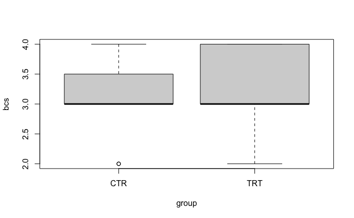

```r
boxplot(bcs~group,data=df)
```

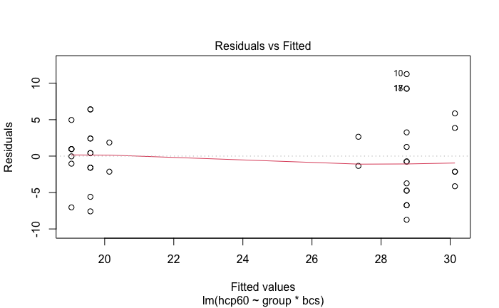

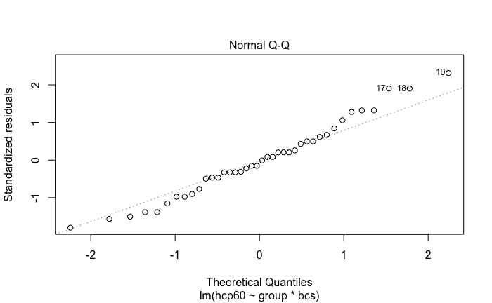

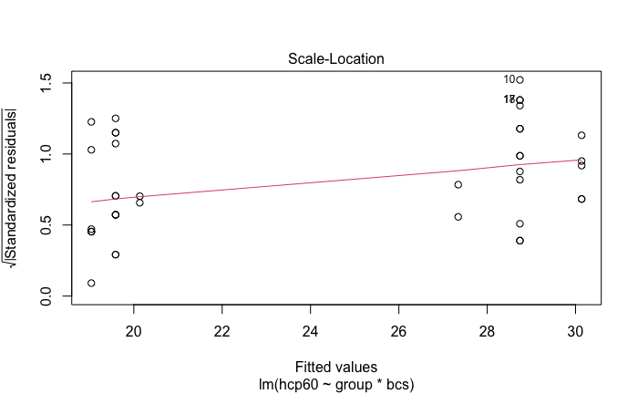

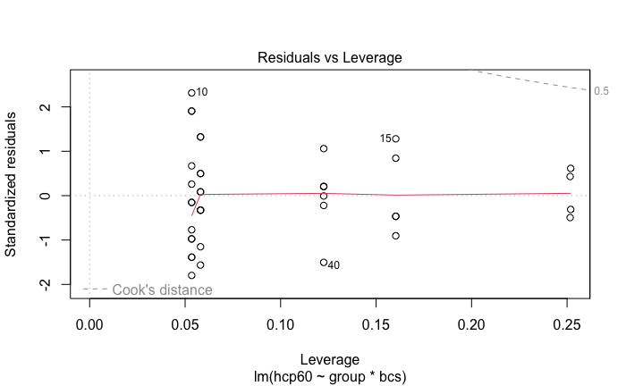

```r
#Boxplots look OK
martello5.lm <- lm(hcp60~group*bcs, data=df)
plot(martello5.lm)
```

```r
summary(martello5.lm)
```

```
Call:
lm(formula = hcp60 ~ group * bcs, data = df)

Residuals:
   Min     1Q Median     3Q    Max
 -8.74  -2.54  -0.39   2.47  11.26

Coefficients:
             Estimate Std. Error t value Pr(>|t|)
(Intercept)     24.55       6.25    3.93  0.00037 ***
groupTRT        -3.32       8.62   -0.38  0.70269
bcs              1.40       1.95    0.72  0.47890
groupTRT:bcs    -1.95       2.65   -0.73  0.46798
---
Signif. codes:  0 ‘***’ 0.001 ‘**’ 0.01 ‘*’ 0.05 ‘.’ 0.1 ‘ ’ 1

Residual standard error: 5 on 36 degrees of freedom
Multiple R-squared:  0.505, Adjusted R-squared:  0.464
F-statistic: 12.3 on 3 and 36 DF,  p-value: 1.13e-05
```

```r
Anova(martello5.lm, type='III')
```

```
Anova Table (Type III tests)

Response: hcp60
            Sum Sq Df F value  Pr(>F)
(Intercept)    385  1   15.43 0.00037 ***
group            4  1    0.15 0.70269
bcs             13  1    0.51 0.47890
group:bcs       13  1    0.54 0.46798
Residuals      899 36
---
Signif. codes:  0 ‘***’ 0.001 ‘**’ 0.01 ‘*’ 0.05 ‘.’ 0.1 ‘ ’ 1
```

```r
emmeans(martello5.lm, ~ group:bcs)
```

```
 group bcs emmean   SE df lower.CL upper.CL
 CTR   3.2   29.0 1.12 36     26.8     31.3
 TRT   3.2   19.5 1.12 36     17.2     21.8

Confidence level used: 0.95
```

> This model fits worst of all!

> Interestingly, the explanatory variables sex, sterilization and bcs improve the fit of the model marginally, and they don’t change the sensitivity much. If we were to analyse the data just using the treatments, i.e. as a one-way ANOVA, we’d see that the model fits a bit worse (though still r/^2 around 0.5), but the confidence intervals around the treatment effect are a bit better, because in fitting a more complex model, we’ve used up degrees of freedom, without reducing the residual SS very much

```r
martello6.lm<-lm(hcp60~group, data=df)
summary(martello6.lm)
```

```
Call:
lm(formula = hcp60 ~ group, data = df)

Residuals:
   Min     1Q Median     3Q    Max
 -8.95  -2.95  -0.70   2.55  11.05

Coefficients:
            Estimate Std. Error t value Pr(>|t|)
(Intercept)    28.95       1.10   26.40  < 2e-16 ***
groupTRT       -9.50       1.55   -6.13  3.8e-07 ***
---
Signif. codes:  0 ‘***’ 0.001 ‘**’ 0.01 ‘*’ 0.05 ‘.’ 0.1 ‘ ’ 1

Residual standard error: 4.9 on 38 degrees of freedom
Multiple R-squared:  0.497, Adjusted R-squared:  0.484
F-statistic: 37.5 on 1 and 38 DF,  p-value: 3.83e-07
```

```r
emmeans(martello6.lm, ~group)
```

```
 group emmean  SE df lower.CL upper.CL
 CTR     28.9 1.1 38     26.7     31.2
 TRT     19.4 1.1 38     17.2     21.7

Confidence level used: 0.95
```

**Other things to consider**

As you work through later chapters, we’ll use this data set to explore a few other things: 1. See whether body weight plays a role in the response. Dosage rates were adjusted for body weight, but there are other considerations around forces acting on joints, etc. 2. Make use of the 3 measurements on each dog and see if we can see any more subtle aspects of the response 3. Take a look at the vet data; with only 5 values, it might be better not to try and force it into an analysis that presumes a normal distribution.

### D

We’ll return to the example from the Chapter 6 exercises, where Vosteen et al (2016) examined patterns of production of honeydew by different races of pea aphids (*Acyrthosiphon pisum*) and how that attracts ovipositioning hoverflies (*Episyrphus balteatus*) to create enemy-free space for the aphids. They measured honeydew production in response to combinations of aphid races and native/universal hosts, and treated these combinations as a single factor.

We could view aphid race and whether the aphids were on their native host or a universal one. Use the modified data file to see what happens when you separate these factors.

> Get the data file

```r
#Read in the data and assign it to an object df
df <- read_csv("data/vosteen.csv")
head(df,10)
```

| clone_plant_combination | honeydew | clone | plant | hostplant |
| --- | --- | --- | --- | --- |
| T_Vicia | 1.08 | T | Vicia | Universal |
| T_Vicia | 2.21 | T | Vicia | Universal |
| T_Vicia | 2.63 | T | Vicia | Universal |
| T_Vicia | 1.63 | T | Vicia | Universal |
| T_Vicia | 3.51 | T | Vicia | Universal |
| T_Vicia | 2.53 | T | Vicia | Universal |
| T_Vicia | 2.92 | T | Vicia | Universal |
| T_Vicia | 0.98 | T | Vicia | Universal |
| T_Vicia | 2.39 | T | Vicia | Universal |
| T_Vicia | 2.05 | T | Vicia | Universal |

```r
#Make sure clone and hostplant are factors
df$clone<-as.factor(df$clone)
df$hostplant<-as.factor(df$hostplant)
```

Do the usual check of data

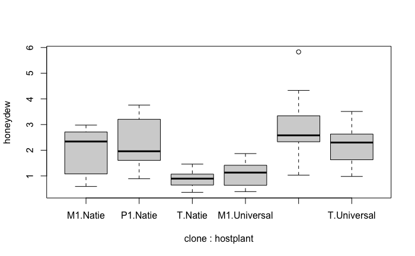

```r
boxplot(honeydew~clone*hostplant, data=df)
```

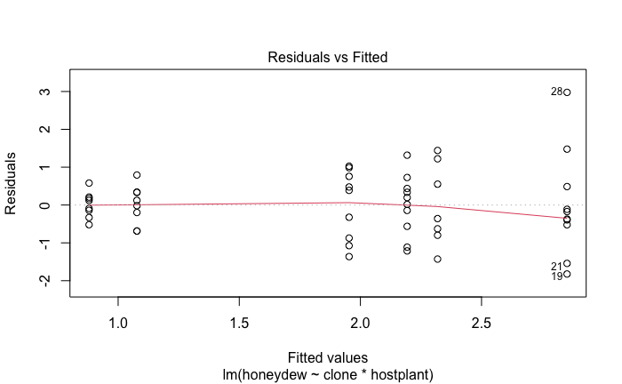

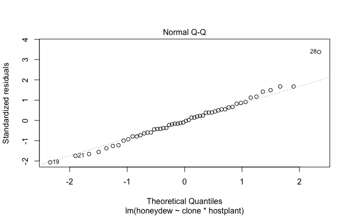

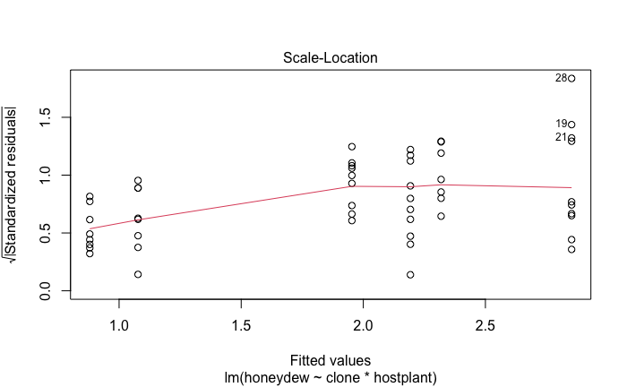

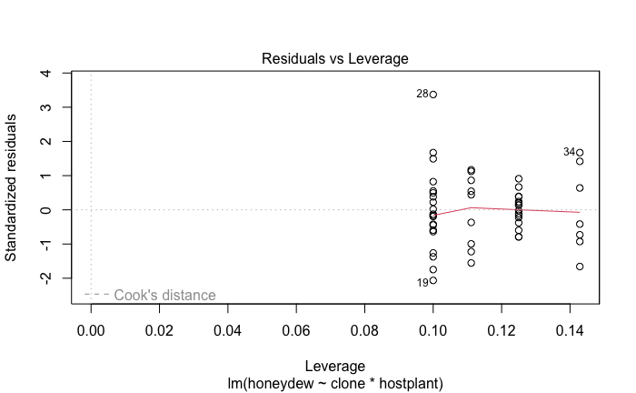

```r
vost.lm<-lm(honeydew~clone*hostplant, data=df, contrasts=list(clone=contr.sum, hostplant=contr.sum))
plot(vost.lm)
```

Diagnostics look OK. Assess model fit and get estimates

```r
summary(vost.lm)
```

```
Call:
lm(formula = honeydew ~ clone * hostplant, data = df, contrasts = list(clone = contr.sum,
    hostplant = contr.sum))

Residuals:
    Min      1Q  Median      3Q     Max
-1.8230 -0.5330 -0.0538  0.4793  2.9770

Coefficients:
                  Estimate Std. Error t value Pr(>|t|)
(Intercept)          1.879      0.130   14.44  < 2e-16 ***
clone1              -0.364      0.184   -1.97  0.05451 .
clone2               0.707      0.186    3.80  0.00042 ***
hostplant1          -0.162      0.130   -1.24  0.21984
clone1:hostplant1    0.600      0.184    3.25  0.00214 **
clone2:hostplant1   -0.105      0.186   -0.57  0.57352
---
Signif. codes:  0 ‘***’ 0.001 ‘**’ 0.01 ‘*’ 0.05 ‘.’ 0.1 ‘ ’ 1

Residual standard error: 0.931 on 46 degrees of freedom
Multiple R-squared:  0.384, Adjusted R-squared:  0.318
F-statistic: 5.75 on 5 and 46 DF,  p-value: 0.000336
```

```r
Anova(vost.lm, type='III')
```

```
Anova Table (Type III tests)

Response: honeydew
                Sum Sq Df F value Pr(>F)
(Intercept)      180.6  1  208.38 <2e-16 ***
clone             12.5  2    7.24 0.0018 **
hostplant          1.3  1    1.55 0.2198
clone:hostplant   10.6  2    6.13 0.0044 **
Residuals         39.9 46
---
Signif. codes:  0 ‘***’ 0.001 ‘**’ 0.01 ‘*’ 0.05 ‘.’ 0.1 ‘ ’ 1
```

```r
emmeans(vost.lm, ~clone | hostplant)
```

```
hostplant = Natie:
 clone emmean    SE df lower.CL upper.CL
 M1      1.95 0.310 46    1.329     2.58
 P1      2.32 0.352 46    1.610     3.03
 T       0.88 0.329 46    0.217     1.54

hostplant = Universal:
 clone emmean    SE df lower.CL upper.CL
 M1      1.08 0.329 46    0.415     1.74
 P1      2.85 0.294 46    2.260     3.45
 T       2.19 0.294 46    1.600     2.79

Confidence level used: 0.95
```

> The analysis suggests a somewhat complex picture, with an interaction between clone and hostplant, i.e. the difference in honeydew production between native and universal hosts varies with aphid clone. We can see it clearly from the cell means above, but it always helps to visualize it.

```
dv column detected: honeydew
No id column passed. Assuming all rows are independent samples.
```

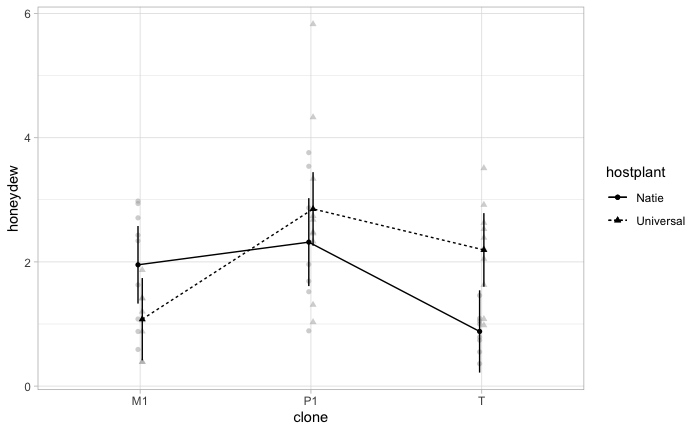

```r
afex_plot(vost.lm, "clone", "hostplant", dodge=0.05)+theme_light()
```

> The direction of the difference reverses for clone M1